# Analysis of OMICS data PR

Marker gene amplification metagenomics in practice

Author

Affiliation

Ágoston Hunya, Eszter Ari

Eötvös Loránd University, Budapest & Biological Research Centre, Szeged

Published

July 17, 2026

**Here you can find some useful lectures and explanations about the *Marker gene amplification metagenomics*:**

1. The first two videos of *Microbiome Discovery* by Dan Knights (although if you are interested, it can be recommended to watch all):
2. [Microbiome Discovery 1: Microbiome Discovery 1: Intro to the Microbiome](https://www.youtube.com/watch?v=6564K4-_DBI&list=PLOPiWVjg6aTzsA53N19YqJQeZpSCH9QPc&index=2)
3. [Microbiome Discovery 2: How microbiome data are generated](https://www.youtube.com/watch?v=FWT1HBzlWOE&list=PLOPiWVjg6aTzsA53N19YqJQeZpSCH9QPc&index=3)
4. To learn the main differences between amplicon and metagenomics sequencing please also go through on this external [website](https://astrobiomike.github.io/misc/amplicon_and_metagen).

**The description of the practical is based on the [DADA2 Pipeline Tutorial](https://benjjneb.github.io/dada2/tutorial.html)**

# Description of the practical

At this practical we will use the `RStudio Server` of the *dlab* server: https://rstudio.dlab.elte.hu/.

The **Questions** will be denoted as follows:

**T0 Q0**

Questions to solve go here.

**Answer**

Answer goes here.

## **Task 1:** Setting up the environment

- Create a directory named Marker_gene_amplification_metagenomics in your home directory.
- Create a new `Project` in `RStudio server` into this directory.
- Open a new `R Script` file and save it.

# Introduction

**A general overview of workflows for analysis of amplicon sequencing data:**

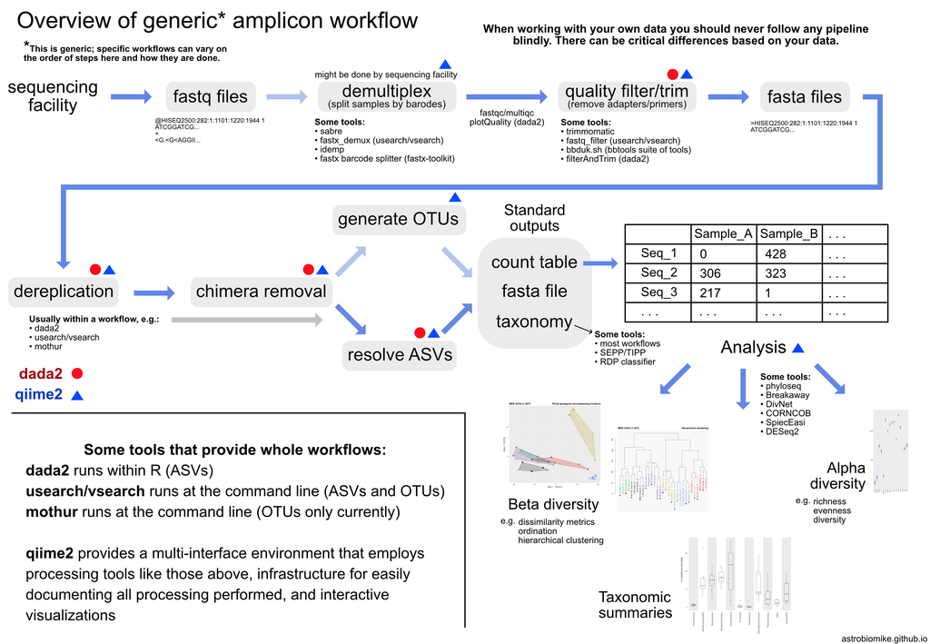

source of the figure: https://astrobiomike.github.io/

We will walk through of the [`dada2`](https://benjjneb.github.io/dada2/index.html) pipeline on a small multi-sample dataset. Our starting point is a set of *Illumina*-sequenced paired-end fastq files that have been split (or “demultiplexed”) by sample and from which the barcodes/adapters have already been removed. The end product is an **amplicon sequence variant (ASV) table**, a higher-resolution analogue of the traditional *OTU table*, which records the number of times each exact amplicon sequence variant (Callahan, McMurdie, and Holmes 2017) was observed in each sample. We also *assign taxonomy* to the output sequences, and demonstrate how the data can be imported into the popular [`phyloseq`](https://joey711.github.io/phyloseq/) `R` `Bioconductor` package for the analysis of microbiome data.

## Starting point

This workflow assumes that your sequencing data meets certain criteria:

- Samples have been **demultiplexed**, *i.e.* split into individual per-sample fastq files.
- Non-biological nucleotides have been removed, *e.g.* primers, adapters, linkers, *etc.*
- If paired-end sequencing data, the forward and reverse fastq files contain reads in matched order.

# Getting ready

## Description of the experiment

In this tutorial we use the [dataset generated by the Schloss lab](https://mothur.org/wiki/Analysis_examples).

The Schloss lab is interested in understanding the effect of normal variation in the gut microbiome on host health. To that end, they collected fresh faeces from mice on a daily basis for 365 days post weaning. During the first 150 days post weaning (dpw), nothing was done to our mice except allow them to eat, get fat, and be merry. They were curious whether the rapid change in weight observed during the first 10 dpw affected the stability microbiome compared to the microbiome observed between days 140 and 150.

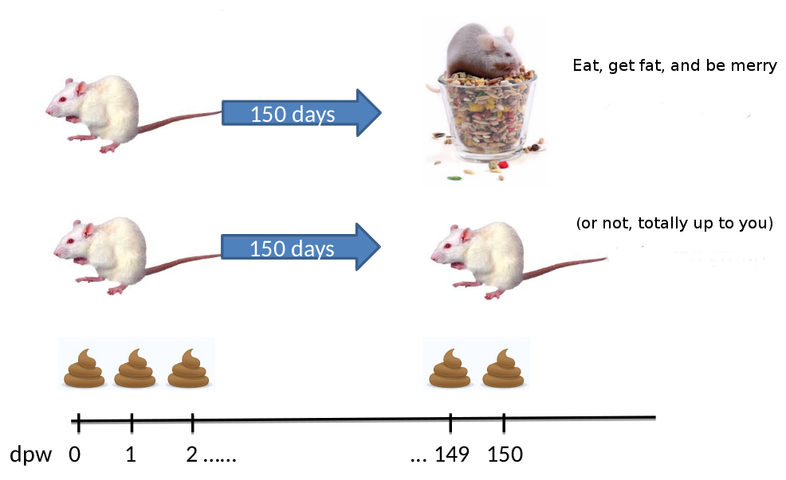

## Reading the data in

To follow along, copy the /shared/BSU2026/Metagenomics/MiSeq_SOP/ folder of the server (or download the [example data](http://www.mothur.org/w/images/d/d6/MiSeqSOPData.zip) and unzip) into your Marker_gene_amplification_metagenomics folder in your home directory.

**Hint: copying the example data from the server**

Open a terminal and copy the folder into your practical directory:

```bash
cp -r /shared/BSU2026/Metagenomics/MiSeq_SOP \
  ~/Marker_gene_amplification_metagenomics/
```

These fastq files were generated by 2x250 *Illumina MiSeq* amplicon sequencing of the *V4 variable region of the 16S rRNA gene* from gut samples collected longitudinally from a mouse post-weaning. For now, just consider them paired-end fastq files to be processed.

First we load the `dada2` `R` `Bioconductor` package.

```r
library(dada2)
# Write the path of the files here.
# Don't use the shared folder directly since we will write into this path later on.
path <- "MiSeq_SOP"
list.files(path)
```

```
 [1] "F3D0_S188_L001_R1_001.fastq"         "F3D0_S188_L001_R2_001.fastq"
 [3] "F3D1_S189_L001_R1_001.fastq"         "F3D1_S189_L001_R2_001.fastq"
 [5] "F3D141_S207_L001_R1_001.fastq"       "F3D141_S207_L001_R2_001.fastq"
 [7] "F3D142_S208_L001_R1_001.fastq"       "F3D142_S208_L001_R2_001.fastq"
 [9] "F3D143_S209_L001_R1_001.fastq"       "F3D143_S209_L001_R2_001.fastq"
[11] "F3D144_S210_L001_R1_001.fastq"       "F3D144_S210_L001_R2_001.fastq"
[13] "F3D145_S211_L001_R1_001.fastq"       "F3D145_S211_L001_R2_001.fastq"
[15] "F3D146_S212_L001_R1_001.fastq"       "F3D146_S212_L001_R2_001.fastq"
[17] "F3D147_S213_L001_R1_001.fastq"       "F3D147_S213_L001_R2_001.fastq"
[19] "F3D148_S214_L001_R1_001.fastq"       "F3D148_S214_L001_R2_001.fastq"
[21] "F3D149_S215_L001_R1_001.fastq"       "F3D149_S215_L001_R2_001.fastq"
[23] "F3D150_S216_L001_R1_001.fastq"       "F3D150_S216_L001_R2_001.fastq"
[25] "F3D2_S190_L001_R1_001.fastq"         "F3D2_S190_L001_R2_001.fastq"
[27] "F3D3_S191_L001_R1_001.fastq"         "F3D3_S191_L001_R2_001.fastq"
[29] "F3D5_S193_L001_R1_001.fastq"         "F3D5_S193_L001_R2_001.fastq"
[31] "F3D6_S194_L001_R1_001.fastq"         "F3D6_S194_L001_R2_001.fastq"
[33] "F3D7_S195_L001_R1_001.fastq"         "F3D7_S195_L001_R2_001.fastq"
[35] "F3D8_S196_L001_R1_001.fastq"         "F3D8_S196_L001_R2_001.fastq"
[37] "F3D9_S197_L001_R1_001.fastq"         "F3D9_S197_L001_R2_001.fastq"
[39] "HMP_MOCK.v35.fasta"                  "Mock_S280_L001_R1_001.fastq"
[41] "Mock_S280_L001_R2_001.fastq"         "mouse.dpw.metadata"
[43] "mouse.time.design"                   "silva_nr_v132_train_set.fa.gz"
[45] "silva_species_assignment_v132.fa.gz" "stability.batch"
[47] "stability.files"
```

**Dataset naming scheme**

For this tutorial, you are given 20 pairs of files. For example, the following pair of files: F3D0_S188_L001_R1_001.fastq, F3D0_S188_L001_R2_001.fastq

The first part of the file name indicates the sample: F3D0 here signifies that this sample was obtained from *Female 3* on *Day 0*. The rest of the file name is identical, except for R1 and R2, this is used to indicate the forward and reverse reads respectively.

Now we read in the names of the fastq files, and perform some string manipulation to get matched lists of the forward and reverse fastq files.

**Showing the content of a variable in `R`**

If you create an `R` variable and put the whole expression into parentheses `()`, `R` will automatically show you the content of the variable.

```r
# Forward and reverse fastq filenames have format: SAMPLENAME_R1_001.fastq and
# SAMPLENAME_R2_001.fastq
(fnFs <- sort(list.files(path, pattern="_R1_001.fastq", full.names = TRUE)))
```

```
 [1] "MiSeq_SOP/F3D0_S188_L001_R1_001.fastq"
 [2] "MiSeq_SOP/F3D1_S189_L001_R1_001.fastq"
 [3] "MiSeq_SOP/F3D141_S207_L001_R1_001.fastq"
 [4] "MiSeq_SOP/F3D142_S208_L001_R1_001.fastq"
 [5] "MiSeq_SOP/F3D143_S209_L001_R1_001.fastq"
 [6] "MiSeq_SOP/F3D144_S210_L001_R1_001.fastq"
 [7] "MiSeq_SOP/F3D145_S211_L001_R1_001.fastq"
 [8] "MiSeq_SOP/F3D146_S212_L001_R1_001.fastq"
 [9] "MiSeq_SOP/F3D147_S213_L001_R1_001.fastq"
[10] "MiSeq_SOP/F3D148_S214_L001_R1_001.fastq"
[11] "MiSeq_SOP/F3D149_S215_L001_R1_001.fastq"
[12] "MiSeq_SOP/F3D150_S216_L001_R1_001.fastq"
[13] "MiSeq_SOP/F3D2_S190_L001_R1_001.fastq"
[14] "MiSeq_SOP/F3D3_S191_L001_R1_001.fastq"
[15] "MiSeq_SOP/F3D5_S193_L001_R1_001.fastq"
[16] "MiSeq_SOP/F3D6_S194_L001_R1_001.fastq"
[17] "MiSeq_SOP/F3D7_S195_L001_R1_001.fastq"
[18] "MiSeq_SOP/F3D8_S196_L001_R1_001.fastq"
[19] "MiSeq_SOP/F3D9_S197_L001_R1_001.fastq"
[20] "MiSeq_SOP/Mock_S280_L001_R1_001.fastq"
```

```r
fnRs <- sort(list.files(path, pattern="_R2_001.fastq", full.names = TRUE))
# Extract sample names, assuming filenames have format: SAMPLENAME_XXX.fastq
(sample.names <- sapply(strsplit(basename(fnFs), "_"), `[`, 1))
```

```
 [1] "F3D0"   "F3D1"   "F3D141" "F3D142" "F3D143" "F3D144" "F3D145" "F3D146"
 [9] "F3D147" "F3D148" "F3D149" "F3D150" "F3D2"   "F3D3"   "F3D5"   "F3D6"
[17] "F3D7"   "F3D8"   "F3D9"   "Mock"
```

# Inspect read quality profiles

We start by visualizing the quality profiles of the first two forward reads:

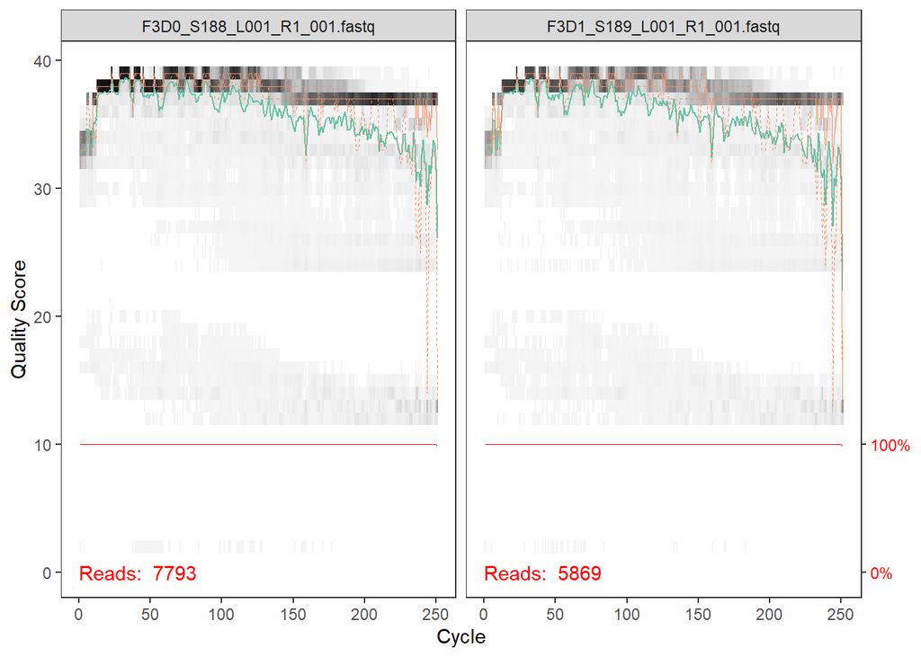

```r
plotQualityProfile(fnFs[1:2])
```

- In grey-scale is a heat map of the frequency of each quality score at each base position.
- The mean quality score at each position is shown by the green line.
- The quartiles of the quality score distribution by the orange lines.
- The red line shows the scaled proportion of reads that extend to at least that position (this is more useful for other sequencing technologies, as Illumina reads are typically all the same length, hence the flat red line).

The forward reads (R1) are good quality. We generally advise trimming the last few nucleotides to avoid less well-controlled errors that can arise there. These quality profiles do not suggest that any additional trimming is needed. We will truncate the forward reads at position 240 (trimming the last 10 nucleotides).

## **Task 2:** Inspect read quality profiles of the reverse reads

Create a letter or a document where you insert the number of the questions and your answer.

**T2 Q1**

Visualize the quality profile of the first two **reverse reads** and insert the figure to the document.

**Answer**

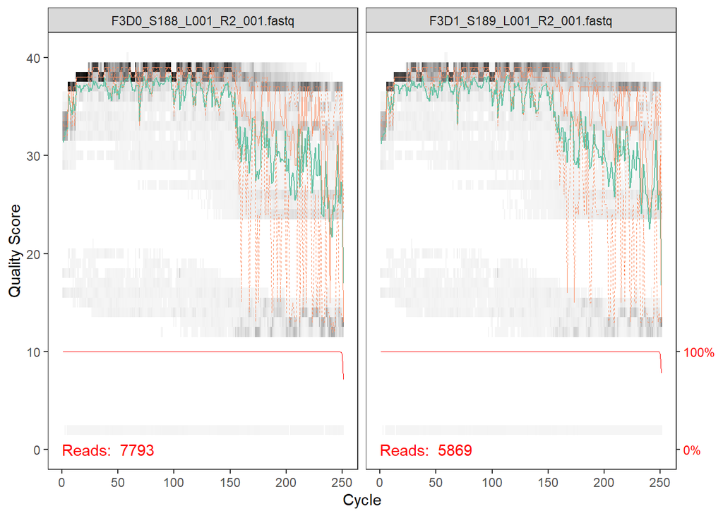

**T2 Q2**

Insert the code also.

**Answer**

```r
plotQualityProfile(fnRs[1:2])
```

**T2 Q3**

Is the quality of the **reverse reads** better or worse compared to the quality of the **forward reads**?

**Answer**

The quality of the **reverse reads is worse** than the quality of the forward reads.

**T2 Q4**

From where would you truncate the **reverse reads** to avoid low quality parts?

**Answer**

The reverse reads should be truncated at approximately **150–160 nucleotides**. In the filtering step, a truncation length of **160 nucleotides** is used.

# Filter and trim

Assign the file names for the filtered fastq.gz files.

```r
# Create an output directory
outpath <- "MiSeq_SOP_output"
# Place filtered files in filtered/ subdirectory
filtFs <- file.path(outpath, "filtered", paste0(sample.names, "_F_filt.fastq.gz"))
filtRs <- file.path(outpath, "filtered", paste0(sample.names, "_R_filt.fastq.gz"))
names(filtFs) <- sample.names
names(filtRs) <- sample.names
# Inspecting the filtFs vector
head(filtFs)
```

```
                                              F3D0
  "MiSeq_SOP_output/filtered/F3D0_F_filt.fastq.gz"
                                              F3D1
  "MiSeq_SOP_output/filtered/F3D1_F_filt.fastq.gz"
                                            F3D141
"MiSeq_SOP_output/filtered/F3D141_F_filt.fastq.gz"
                                            F3D142
"MiSeq_SOP_output/filtered/F3D142_F_filt.fastq.gz"
                                            F3D143
"MiSeq_SOP_output/filtered/F3D143_F_filt.fastq.gz"
                                            F3D144
"MiSeq_SOP_output/filtered/F3D144_F_filt.fastq.gz"
```

We’ll use standard filtering parameters: `maxN = 0` (`dada2` requires no *N*s), `truncQ = 2`, `rm.phix = TRUE` and `maxEE = 2`. The `maxEE` parameter sets the maximum number of “expected errors” allowed in a read, which is a better filter than simply averaging quality scores (Robert C. Edgar and Flyvbjerg 2015).

```r
# Based on the quality profiles, we truncate the forward reads at position 240
# and the reverse reads at 160
out <- filterAndTrim(fwd = fnFs, filt = filtFs,
                     rev = fnRs, filt.rev = filtRs,
                     truncLen = c(240, 160),
                     maxEE = c(2, 2),
                     multithread = FALSE) # On Windows set multithread=FALSE
# Inspecting the resulted out variable
head(out)
```

```
                              reads.in reads.out
F3D0_S188_L001_R1_001.fastq       7793      7113
F3D1_S189_L001_R1_001.fastq       5869      5299
F3D141_S207_L001_R1_001.fastq     5958      5463
F3D142_S208_L001_R1_001.fastq     3183      2914
F3D143_S209_L001_R1_001.fastq     3178      2941
F3D144_S210_L001_R1_001.fastq     4827      4312
```

The filtered and trimmed reads will appear in the filtered folder of your path.

# Learn the error rates

The `dada2` algorithm makes use of a parametric error model (`err`) and every amplicon dataset has a different set of error rates. The `learnErrors` method learns this error model from the data, by alternating estimation of the error rates and inference of sample composition until they converge on a jointly consistent solution. As in many machine-learning problems, the algorithm must begin with an initial guess, for which the maximum possible error rates in this data are used (the error rates if only the most abundant sequence is correct and all the rest are errors).

*The following steps may take some minutes:*

```r
errF <- learnErrors(filtFs, multithread = TRUE)
```

```
33514080 total bases in 139642 reads from 20 samples will be used for learning the error rates.
```

```r
errR <- learnErrors(filtRs, multithread = TRUE)
```

```
22342720 total bases in 139642 reads from 20 samples will be used for learning the error rates.
```

It is always worthwhile, as a sanity check if nothing else, to visualize the estimated error rates:

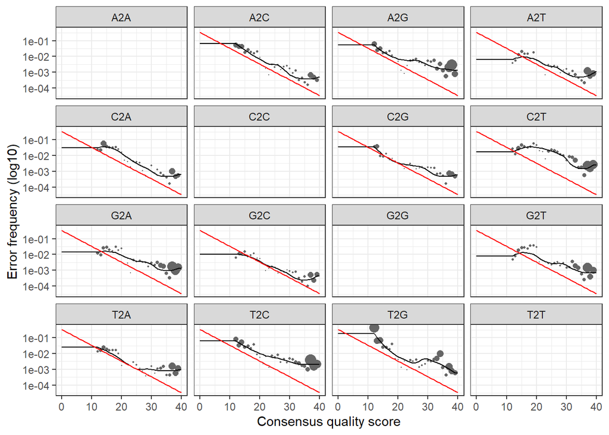

```r
plotErrors(errF, nominalQ = TRUE)
```

The error rates for each possible transition (A→C, A→G, …) are shown. Points are the *observed error rates* for each *consensus quality score*. The *black line* shows the **estimated error rates** after convergence of the machine-learning algorithm. The red line shows the **error rates expected** under the nominal definition of the *Q*-score. Here the estimated error rates (black line) are a good fit to the observed rates (points), and the error rates drop with increased quality as expected. Everything looks reasonable and we proceed with confidence.

# Sample inference

We are now ready to apply the core sample inference algorithm (Callahan et al. 2016) to the filtered and trimmed sequence data.

```r
dadaFs <- dada(filtFs, err = errF, multithread = TRUE)
```

```
Sample 1 - 7113 reads in 1979 unique sequences.
Sample 2 - 5299 reads in 1639 unique sequences.
Sample 3 - 5463 reads in 1477 unique sequences.
Sample 4 - 2914 reads in 904 unique sequences.
Sample 5 - 2941 reads in 939 unique sequences.
Sample 6 - 4312 reads in 1267 unique sequences.
Sample 7 - 6741 reads in 1756 unique sequences.
Sample 8 - 4560 reads in 1438 unique sequences.
Sample 9 - 15637 reads in 3590 unique sequences.
Sample 10 - 11413 reads in 2762 unique sequences.
Sample 11 - 12017 reads in 3021 unique sequences.
Sample 12 - 5032 reads in 1566 unique sequences.
Sample 13 - 18075 reads in 3707 unique sequences.
Sample 14 - 6250 reads in 1479 unique sequences.
Sample 15 - 4052 reads in 1195 unique sequences.
Sample 16 - 7369 reads in 1832 unique sequences.
Sample 17 - 4765 reads in 1183 unique sequences.
Sample 18 - 4871 reads in 1382 unique sequences.
Sample 19 - 6504 reads in 1709 unique sequences.
Sample 20 - 4314 reads in 897 unique sequences.
```

```r
dadaRs <- dada(filtRs, err = errR, multithread = TRUE)
```

```
Sample 1 - 7113 reads in 1660 unique sequences.
Sample 2 - 5299 reads in 1349 unique sequences.
Sample 3 - 5463 reads in 1335 unique sequences.
Sample 4 - 2914 reads in 853 unique sequences.
Sample 5 - 2941 reads in 880 unique sequences.
Sample 6 - 4312 reads in 1286 unique sequences.
Sample 7 - 6741 reads in 1803 unique sequences.
Sample 8 - 4560 reads in 1265 unique sequences.
Sample 9 - 15637 reads in 3414 unique sequences.
Sample 10 - 11413 reads in 2522 unique sequences.
Sample 11 - 12017 reads in 2771 unique sequences.
Sample 12 - 5032 reads in 1415 unique sequences.
Sample 13 - 18075 reads in 3290 unique sequences.
Sample 14 - 6250 reads in 1390 unique sequences.
Sample 15 - 4052 reads in 1134 unique sequences.
Sample 16 - 7369 reads in 1635 unique sequences.
Sample 17 - 4765 reads in 1084 unique sequences.
Sample 18 - 4871 reads in 1161 unique sequences.
Sample 19 - 6504 reads in 1502 unique sequences.
Sample 20 - 4314 reads in 732 unique sequences.
```

Inspecting the returned `dada-class` object:

```r
# Inspecting Female 3 on the 0th day
dadaFs$F3D0
```

```
dada-class: object describing DADA2 denoising results
128 sequence variants were inferred from 1979 input unique sequences.
Key parameters: OMEGA_A = 1e-40, OMEGA_C = 1e-40, BAND_SIZE = 16
```

The `dada2` algorithm inferred 128 true sequence variants from the 1979 unique sequences in the first sample. There is much more to the `dada-class` return object than this (see `help("dada-class")` for some info), including multiple diagnostics about the quality of each denoised sequence variant, but that is beyond the scope of an introductory tutorial.

## **Task3:** Inspecting inferred sequence variants

**T3 Q1**

How many sequence variants were inferred in the sample of the Female 3 on the 150th day (F3D150)?

**Answer**

```r
dadaFs$F3D150
```

```
dada-class: object describing DADA2 denoising results
113 sequence variants were inferred from 1566 input unique sequences.
Key parameters: OMEGA_A = 1e-40, OMEGA_C = 1e-40, BAND_SIZE = 16
```

A total of **113 sequence variants** were inferred from **1,566 input unique sequences**.

# Merge paired reads

We now merge the forward and reverse reads together to obtain the full denoised sequences. Merging is performed by aligning the denoised forward reads with the reverse-complement of the corresponding denoised reverse reads, and then constructing the merged “contig” sequences. By default, merged sequences are only output if the forward and reverse reads overlap by at least 12 bases, and are identical to each other in the overlap region (but these conditions can be changed via function arguments).

```r
mergers <- mergePairs(dadaFs, filtFs, dadaRs, filtRs, verbose = TRUE)
# Inspecting the merger data.frame from the first sample (F3D0)
head(mergers$F3D0)
```

```
                                                                                                                                                                                                                                                      sequence
1 TACGGAGGATGCGAGCGTTATCCGGATTTATTGGGTTTAAAGGGTGCGCAGGCGGAAGAT…
2 TACGGAGGATGCGAGCGTTATCCGGATTTATTGGGTTTAAAGGGTGCGTAGGCGGCCTGC…
3 TACGGAGGATGCGAGCGTTATCCGGATTTATTGGGTTTAAAGGGTGCGTAGGCGGGCTGT…
4 TACGGAGGATGCGAGCGTTATCCGGATTTATTGGGTTTAAAGGGTGCGTAGGCGGGCTTT…
5 TACGGAGGATGCGAGCGTTATCCGGATTTATTGGGTTTAAAGGGTGCGCAGGCGGACTCT…
6 TACGGAGGATGCGAGCGTTATCCGGATTTATTGGGTTTAAAGGGTGCGTAGGCGGGATGC…
  abundance forward reverse nmatch nmismatch nindel prefer accept
1       579       1       1    148         0      0      1   TRUE
2       470       2       2    148         0      0      2   TRUE
3       449       3       4    148         0      0      1   TRUE
4       430       4       3    148         0      0      2   TRUE
5       345       5       6    148         0      0      1   TRUE
6       282       6       5    148         0      0      2   TRUE
```

The `mergers` object is a list of `data.frame`s from each sample. Each `data.frame` contains the merged `$sequence`, its `$abundance`, and the indices of the `$forward` and `$reverse` sequence variants that were merged. Paired reads that did not exactly overlap were removed by `mergePairs`, further reducing spurious output.

# Abundance table

## Outlook

- *OTUs* are clusters of similar sequences often intended to correspond to some taxonomic rank, such as species. They are used to estimate diversity and account for sequencing error.
- *ASVs* are the inferred unique sequences present in the original sample, after correcting for sequencing and PCR errors.

We can now construct an *ASV* *table*, a higher-resolution version of the *OTU table* produced by traditional methods.

```r
seqtab <- makeSequenceTable(mergers)
# The size of the seqtab
dim(seqtab)
```

```
[1]  20 293
```

```r
# Inspecting the first two column of seqtab
head(seqtab[, 1:2])
```

```
       TACGGAGGATGCGAGCGTTATCCGGATTTATTGGGTTTAAAGGGTGCGCAGGCGGAAGAT…
F3D0                                                                                                                                                                                                                                                            579
F3D1                                                                                                                                                                                                                                                            405
F3D141                                                                                                                                                                                                                                                          444
F3D142                                                                                                                                                                                                                                                          289
F3D143                                                                                                                                                                                                                                                          228
F3D144                                                                                                                                                                                                                                                          421
       TACGGAGGATGCGAGCGTTATCCGGATTTATTGGGTTTAAAGGGTGCGCAGGCGGACTCT…
F3D0                                                                                                                                                                                                                                                            345
F3D1                                                                                                                                                                                                                                                            353
F3D141                                                                                                                                                                                                                                                          362
F3D142                                                                                                                                                                                                                                                          304
F3D143                                                                                                                                                                                                                                                          176
F3D144                                                                                                                                                                                                                                                          277
```

The sequence table is a `matrix` with rows corresponding to (and named by) the samples, and columns corresponding to (and named by) the sequence variants. This table contains 293 *ASVs*, and the lengths of our merged sequences all fall within the expected range for this *V4* amplicon.

# Remove chimeras

The core `dada` method corrects *substitution* and *indel* errors, but *chimeras* remain. Fortunately, the accuracy of sequence variants after denoising makes identifying chimeric ASVs simpler than when dealing with fuzzy OTUs. Chimeric sequences are identified if they can be exactly reconstructed by combining a left-segment and a right-segment from two more abundant “parent” sequences.

```r
# table without chimeric sequences
seqtab.nochim <- removeBimeraDenovo(seqtab,
                                    method = "consensus",
                                    multithread = TRUE)
# its size
dim(seqtab.nochim)
```

```
[1]  20 232
```

```r
# its proportion to the seqtab
sum(seqtab.nochim) / sum(seqtab)
```

```
[1] 0.9640374
```

The frequency of chimeric sequences varies substantially from dataset to dataset, and depends on on factors including experimental procedures and sample complexity. Here chimeras make up about 21% of the merged sequence variants, but when we account for the abundances of those variants we see they account for only about 4% of the merged sequence reads.

## **Task 4:** The proportion of chimeras

**T4 Q1**

What is the proportion of chimeric sequences in the first sample (F3D0)?

**Answer**

The proportion of chimeric sequences in sample **F3D0** is approximately **0.18%** (`0.001834862` as a proportion).

```r
1 - sum(seqtab.nochim[1, ]) / sum(seqtab[1, ])
```

```
[1] 0.001834862
```

# Assign taxonomy

It is common at this point, especially in 16S/18S/ITS amplicon sequencing, to assign taxonomy to the sequence variants. The `dada2` package provides a native implementation of the naive Bayesian classifier method (Wang et al. 2007) for this purpose. The `assignTaxonomy` function takes as input a set of sequences to be classified and a training set of reference sequences with known taxonomy, and outputs taxonomic assignments with at least `minBoot` bootstrap confidence.

A key step in microbiome sequencing analysis is read assignment to taxonomic units. This is often performed using one of four taxonomic classifications, namely [*SILVA*](https://www.arb-silva.de/), [*RDP*](https://www.glbrc.org/data-and-tools/glbrc-data-sets/ribosomal-database-project), [*GreenGenes*](https://ftp.microbio.me/greengenes_release/) or [*NCBI*](https://www.ncbi.nlm.nih.gov/). *SILVA* is a reference database that is a comprehensive on-line resource for quality checked and aligned ribosomal RNA sequence data.

To follow along, the MiSeq_SOP/ folder (copied from the /shared folder) already contains a version of the *SILVA* database as the silva_nr_v132_train_set.fa.gz file (which can also be downloaded from here).

```r
taxa <- assignTaxonomy(seqtab.nochim,
                       "MiSeq_SOP/silva_nr_v132_train_set.fa.gz",
                       multithread = TRUE)
```

**Extensions:**

The `dada2` package also implements a method to make species level assignments based on **exact matching** between ASVs and sequenced reference strains. Recent analysis suggests that exact matching (or 100% identity) is the only appropriate way to assign species to 16S gene fragments (Robert C. Edgar 2018). To follow the optional species addition step, the MiSeq_SOP/ folder (copied from the /shared folder) already contains the silva_species_assignment_v132.fa.gz file (which can also be downloaded from here).

```r
taxa <- addSpecies(taxa,
                  "MiSeq_SOP/silva_species_assignment_v132.fa.gz")
```

Let’s inspect the taxonomic assignments:

```r
taxa.print = taxa # Removing sequence rownames for display only
rownames(taxa.print) = NULL
head(taxa.print)
```

```
     Kingdom    Phylum          Class         Order           Family
[1,] "Bacteria" "Bacteroidetes" "Bacteroidia" "Bacteroidales" "Muribaculaceae"
[2,] "Bacteria" "Bacteroidetes" "Bacteroidia" "Bacteroidales" "Muribaculaceae"
[3,] "Bacteria" "Bacteroidetes" "Bacteroidia" "Bacteroidales" "Muribaculaceae"
[4,] "Bacteria" "Bacteroidetes" "Bacteroidia" "Bacteroidales" "Muribaculaceae"
[5,] "Bacteria" "Bacteroidetes" "Bacteroidia" "Bacteroidales" "Bacteroidaceae"
[6,] "Bacteria" "Bacteroidetes" "Bacteroidia" "Bacteroidales" "Muribaculaceae"
     Genus         Species
[1,] NA            NA
[2,] NA            NA
[3,] NA            NA
[4,] NA            NA
[5,] "Bacteroides" NA
[6,] NA            NA
```

Unsurprisingly, the *Bacteroidetes* are well represented among the most abundant taxa in these faecal samples. Few species assignments were made, both because it is often not possible to make unambiguous species assignments from subsegments of the 16S gene, and because there is surprisingly little coverage of the indigenous mouse gut microbiota in reference databases.

# Analysing the data with `phyloseq`

The [`phyloseq`](https://joey711.github.io/phyloseq/) `Bioconductor` `R` package is a powerful framework for further analysis of microbiome data. We now demonstrate how to straightforwardly import the tables produced by the `dada2` pipeline into `phyloseq`. We’ll also add the small amount of metadata we have – the samples are named by the gender (G), mouse subject number (X) and the day post-weaning (Y) it was sampled (*e.g.* GXDY).

## Import into `phyloseq`

```r
library(phyloseq)
library(Biostrings)
library(ggplot2)
theme_set(theme_bw()) # setting theme for plotting with ggplot2
```

### Metadata of samples

We can construct a simple sample `data.frame` from the information encoded in the file names. Usually this step would instead involve reading the sample data in from a file.

```r
# vector of sample names
samples.out <- rownames(seqtab.nochim)
head(samples.out)
```

```
[1] "F3D0"   "F3D1"   "F3D141" "F3D142" "F3D143" "F3D144"
```

```r
# split the names with character "D"
subject <- sapply(strsplit(samples.out, "D"), `[`, 1)

# gender of the mice
gender <- substr(subject, 1, 1)

# the number of the mice (specimen nr.)
subject = substr(subject, 2, 999)

# the day after birth when the sample was collected
day <- as.integer(sapply(strsplit(samples.out, "D"), `[`, 2))

# a data.frame that contains the above data
samdf <- data.frame(Subject = subject, Gender = gender, Day = day)

# adding a new column to distinguish between samples collected early
# (in the first 100 days) or later on
samdf$When <- "Early"
samdf$When[samdf$Day > 100] <- "Late"

# adding rownames
rownames(samdf) <- samples.out
head(samdf)
```

```
       Subject Gender Day  When
F3D0         3      F   0 Early
F3D1         3      F   1 Early
F3D141       3      F 141  Late
F3D142       3      F 142  Late
F3D143       3      F 143  Late
F3D144       3      F 144  Late
```

### `phyloseq` object

We now construct a `phyloseq` object directly from the `dada2` outputs and also remove the “Mock” community sample. (Mock community is a defined mixture of microbial cells in vitro to simulate the composition of a microbiome sample. Mock communities are used for benchmarking the metagenome experiments and analyses.)

```r
ps <- phyloseq(otu_table(seqtab.nochim, taxa_are_rows = FALSE),
              sample_data(samdf),
              tax_table(taxa))
# Removing the mock sample
ps <- prune_samples(sample_names(ps) != "Mock", ps)
# Inspecting the phyloseq object variable
ps
```

```
phyloseq-class experiment-level object
otu_table()   OTU Table:         [ 232 taxa and 19 samples ]
sample_data() Sample Data:       [ 19 samples by 4 sample variables ]
tax_table()   Taxonomy Table:    [ 232 taxa by 7 taxonomic ranks ]
```

It is more convenient to use short names for our *ASVs* (*e.g.* ASV21) rather than the full DNA sequence when working with some of the tables and visualizations from `phyloseq`, but we want to keep the full DNA sequences for other purposes. For that reason we’ll store the DNA sequences of our *ASVs* in the `refseq` slot of the `phyloseq` object, and then rename our taxa to a short string. That way, the short new taxa names will appear in tables and plots, and we can still recover the DNA sequences corresponding to each *ASV* as needed with `refseq(ps)`.

```r
dna <- Biostrings::DNAStringSet(taxa_names(ps))
names(dna) <- taxa_names(ps)
ps <- merge_phyloseq(ps, dna)
taxa_names(ps) <- paste0("ASV", seq(ntaxa(ps)))
# Inspecting the phyloseq object variable
ps
```

```
phyloseq-class experiment-level object
otu_table()   OTU Table:         [ 232 taxa and 19 samples ]
sample_data() Sample Data:       [ 19 samples by 4 sample variables ]
tax_table()   Taxonomy Table:    [ 232 taxa by 7 taxonomic ranks ]
refseq()      DNAStringSet:      [ 232 reference sequences ]
```

We are now ready to use `phyloseq`!

## Abundance plot

Let’s create a plot that shows the abundances of the *top20 taxa* from samples of each day and colour the plot by the *Family level* taxonomic assignment.

```r
# top20 taxa
top20 <- names(sort(taxa_sums(ps), decreasing = TRUE))[1:20]

# Creating a phyloseq object that contains the top20 taxa only while
# transforming data to proportions for plotting
ps.top20 <- transform_sample_counts(ps, function(OTU) OTU / sum(OTU))
ps.top20 <- prune_taxa(top20, ps.top20)
# Inspecting the ps.top20 phyloseq object variable
ps.top20
```

```
phyloseq-class experiment-level object
otu_table()   OTU Table:         [ 20 taxa and 19 samples ]
sample_data() Sample Data:       [ 19 samples by 4 sample variables ]
tax_table()   Taxonomy Table:    [ 20 taxa by 7 taxonomic ranks ]
refseq()      DNAStringSet:      [ 20 reference sequences ]
```

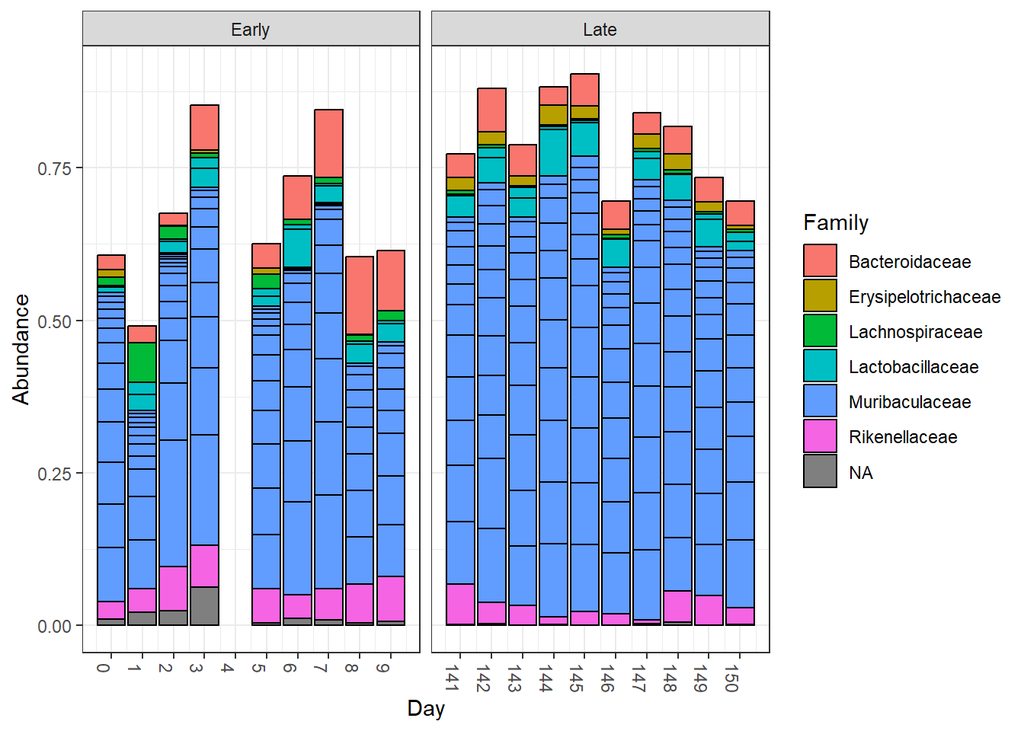

```r
# barplot
plot_bar(ps.top20, x = "Day", fill = "Family") +
  facet_wrap(~When, scales = "free_x") +
  scale_x_continuous(breaks = 0:150)
```

## **Task 5:** Abundance

**T5 Q1**

Can you see any pattern in the taxa that explains the early-late differentiation?

**Answer**

## Visualize alpha diversities

In ecology, alpha diversity (α-diversity) is the mean species diversity in sites or habitats at a local scale. The term was introduced by R. H. Whittaker together with the terms beta diversity (β-diversity) and gamma diversity (γ-diversity). Whittaker’s idea was that the total species diversity in a landscape (gamma diversity) is determined by two different things, the mean species diversity in sites or habitats at a more local scale (alpha diversity) and the differentiation among those habitats (beta diversity). Read more [here](https://en.wikipedia.org/wiki/Alpha_diversity).

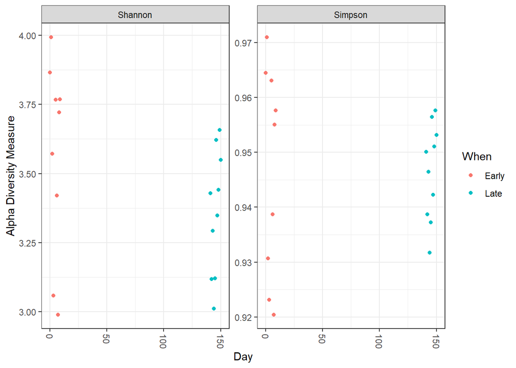

```r
plot_richness(ps, x = "Day", measures = c("Shannon", "Simpson"), color = "When")
```

## **Task 6:** Alpha diversities

**T6 Q1**

What difference can you see between the early and the late stages of the microbiomes based on the alpha diversities?

**Answer**

The early-stage samples show greater variability in alpha diversity than the late-stage samples. This indicates that the early microbiomes are less similar to one another, whereas the late microbiomes are more stable and homogeneous.

## Beta diversities

```r
# Transforming data to proportions as appropriate for Bray-Curtis distances
ps.prop <- transform_sample_counts(ps, function(OTU) OTU / sum(OTU))
ord.nmds.bray <- ordinate(ps.prop, method = "NMDS", distance = "bray")
```

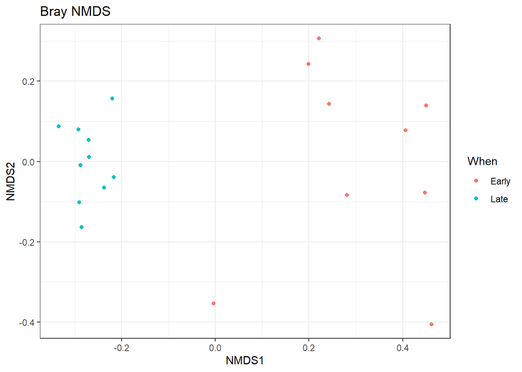

```r
# Plotting the Beta diversities (distances between the samples) on a
# multidimensional scaling plot with PCoA (Principal Coordinate Analysis)
plot_ordination(ps.prop, ord.nmds.bray, color = "When", title = "Bray NMDS")
```

Ordination picks out a clear separation between the early and late samples.

These were minimal examples of what can be done with `phyloseq`, for more examples go [the phyloseq web site](https://joey711.github.io/phyloseq/)!

## References

Callahan, Benjamin J., Paul J. McMurdie, and Susan P. Holmes. 2017. “Exact Sequence Variants Should Replace Operational Taxonomic Units in Marker-Gene Data Analysis.” *The ISME Journal* 11 (12): 2639–43. https://doi.org/10.1038/ismej.2017.119.

Callahan, Benjamin J., Paul J. McMurdie, Michael J. Rosen, Andrew W. Han, Amy Jo A. Johnson, and Susan P. Holmes. 2016. “DADA2: High-Resolution Sample Inference from Illumina Amplicon Data.” *Nature Methods* 13 (7): 581–83. https://doi.org/10.1038/nmeth.3869.

Edgar, Robert C. 2018. “Updating the 97% Identity Threshold for 16S Ribosomal RNA OTUs.” *Bioinformatics* 34 (14): 2371–75. https://doi.org/10.1093/bioinformatics/bty113.

Edgar, Robert C., and Henrik Flyvbjerg. 2015. “Error Filtering, Pair Assembly and Error Correction for Next-Generation Sequencing Reads.” *Bioinformatics* 31 (21): 3476–82. https://doi.org/10.1093/bioinformatics/btv401.

Wang, Qiong, George M. Garrity, James M. Tiedje, and James R. Cole. 2007. “Naive Bayesian Classifier for Rapid Assignment of rRNA Sequences into the New Bacterial Taxonomy.” *Applied and Environmental Microbiology* 73 (16): 5261–67. https://doi.org/10.1128/AEM.00062-07.